# R Notebook

Connor Johnson

```r
library(ISLR)
library(ggplot2)
library(dplyr)
library(reshape2)
library("writexl")
write.csv(College, "College.csv")
```

## Problem 2

## Exercise 1

1. A flexible model would be better in this case. Since n is large, we are able to better estimate a larger number of parameters which would be done using a more flexible model.
2. Since there is a large number of parameters, there will be more error in the model. With a small sample size, it is more difficult to accurately estimate all the parameters. A flexible model would likely be overfit causing more error in the test data. Because of this, an inflexible method would be better.
3. A flexible learning method is better in this case. Inflexible methods create more linear approximation of the relationship between the predictors and the response. Since this relatioship is nonlinear, a flexible method is better in approximating it.
4. An inflexible learning method would be better. Because of the high varaince in the error terms, a flexible method is likely to overfit to account for this error. The model would then be bad at predicting the test set. So, an inflexible method is better.

## Exercise 2

1. This scenario is a regression problem because the response variable is quantitative. We are more interested in inferfence because we’re just looking for a general understanding of what factors affect a CEO’s salary. There is no intention to predict different CEO’s salaries using the model that is created. Finally, n is 500 firms. p is 3; the three predictors are profit, number of employees, and the industry.
2. This scenario is a classification because the response variable is discrete; success or failure. We are more interested in prediction because the goal is to use the model to predict the outcome of another product. n is 20 products and p is 13; the predictors are price, marketing budget, competition price, and ten other variables not mentioned
3. This scenario is a regression problem because the response variable is quantitive, the percent change in the exchange rate. We are more interested in prediction because the goal is to use the model to project what the changes in the exchange rate will be based on the data. n is 52 weeks and p is 3; the predictors are percent change in the US market, the percent change in the British market, and the percent change in the German market.

## Exercise 5

A flexible model is more advantageous for when the relationship between the predictors and the response is non-linear. A less flexible approach toward this type of relationship would have more error. The flexible approach also reduces the error when using the model the make predictions. Inflexible approaches have more bias wwhich results in more error when using it on the test set.

The main disadvantage of using a flexible approach is overfitting. If a too flexible approach is used the model will have very low error on the training data, but can have greater error when used to predict new data. This is because the model overfits small changes in the response variable that shouldn’t be considered when predicting new data.

Flexible approaches are much better for nonlinear models and for predivtion models. Since flexible models account more for small changes in data, they are much better at then predicting new data. Less flexible models are better for more linear relationships and inference. Since you’re only looking for more broad understanding of the data, there is no need to use a flexible approach which could overfit the data.

## Exercise 8

```r
college = read.csv("College.csv")
```

```r
fix(college)
rownames(college) = college[,1]
fix(college)
college = college[,-1]
fix(college)
```

```r
summary(college)
```

```
   Private               Apps           Accept          Enroll       Top10perc       Top25perc
 Length:777         Min.   :   81   Min.   :   72   Min.   :  35   Min.   : 1.00   Min.   :  9.0
 Class :character   1st Qu.:  776   1st Qu.:  604   1st Qu.: 242   1st Qu.:15.00   1st Qu.: 41.0
 Mode  :character   Median : 1558   Median : 1110   Median : 434   Median :23.00   Median : 54.0
                    Mean   : 3002   Mean   : 2019   Mean   : 780   Mean   :27.56   Mean   : 55.8
                    3rd Qu.: 3624   3rd Qu.: 2424   3rd Qu.: 902   3rd Qu.:35.00   3rd Qu.: 69.0
                    Max.   :48094   Max.   :26330   Max.   :6392   Max.   :96.00   Max.   :100.0
  F.Undergrad     P.Undergrad         Outstate       Room.Board       Books           Personal
 Min.   :  139   Min.   :    1.0   Min.   : 2340   Min.   :1780   Min.   :  96.0   Min.   : 250
 1st Qu.:  992   1st Qu.:   95.0   1st Qu.: 7320   1st Qu.:3597   1st Qu.: 470.0   1st Qu.: 850
 Median : 1707   Median :  353.0   Median : 9990   Median :4200   Median : 500.0   Median :1200
 Mean   : 3700   Mean   :  855.3   Mean   :10441   Mean   :4358   Mean   : 549.4   Mean   :1341
 3rd Qu.: 4005   3rd Qu.:  967.0   3rd Qu.:12925   3rd Qu.:5050   3rd Qu.: 600.0   3rd Qu.:1700
 Max.   :31643   Max.   :21836.0   Max.   :21700   Max.   :8124   Max.   :2340.0   Max.   :6800
      PhD            Terminal       S.F.Ratio      perc.alumni        Expend        Grad.Rate
 Min.   :  8.00   Min.   : 24.0   Min.   : 2.50   Min.   : 0.00   Min.   : 3186   Min.   : 10.00
 1st Qu.: 62.00   1st Qu.: 71.0   1st Qu.:11.50   1st Qu.:13.00   1st Qu.: 6751   1st Qu.: 53.00
 Median : 75.00   Median : 82.0   Median :13.60   Median :21.00   Median : 8377   Median : 65.00
 Mean   : 72.66   Mean   : 79.7   Mean   :14.09   Mean   :22.74   Mean   : 9660   Mean   : 65.46
 3rd Qu.: 85.00   3rd Qu.: 92.0   3rd Qu.:16.50   3rd Qu.:31.00   3rd Qu.:10830   3rd Qu.: 78.00
 Max.   :103.00   Max.   :100.0   Max.   :39.80   Max.   :64.00   Max.   :56233   Max.   :118.00
```

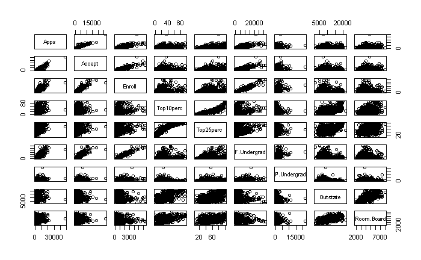

```r
pairs(college[,2:10])
```

```r
boxplot(college$Private, college$Outstate)
```

```
Error in x[floor(d)] + x[ceiling(d)] :
  non-numeric argument to binary operator
```

[figure not shown]

```r
par(mfrow=c(2,2))
hist(college$F.Undergrad, breaks=4)
hist(college$Accept)
```

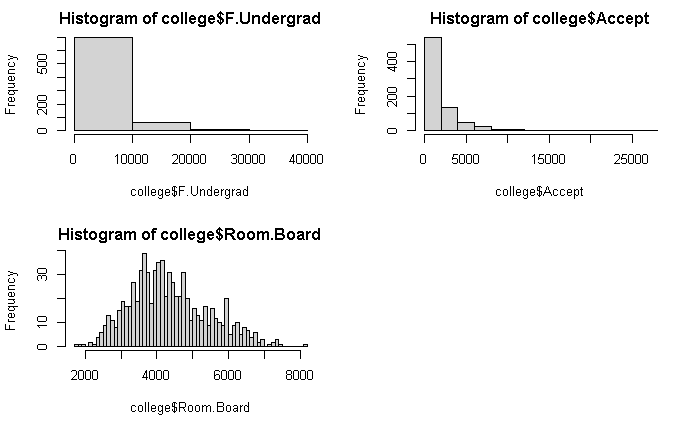

```r
hist(college$Room.Board, breaks=50)
hist(college$Grad.Rate)
```

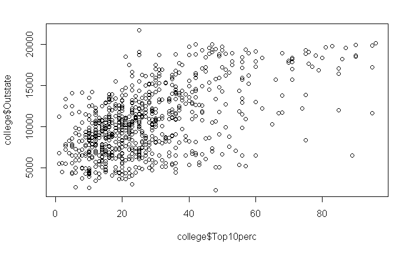

```r
plot(college$Top10perc, college$Outstate)
```

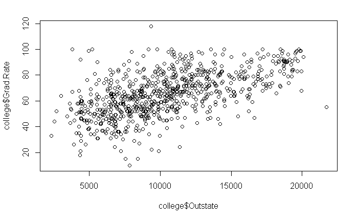

```r
## This plot shows somewhat of a correlation between the percentage of students in the top of their class and tuition. This shows that schools with smarter students tend to be more expensive

plot(college$Outstate, college$Grad.Rate)
```

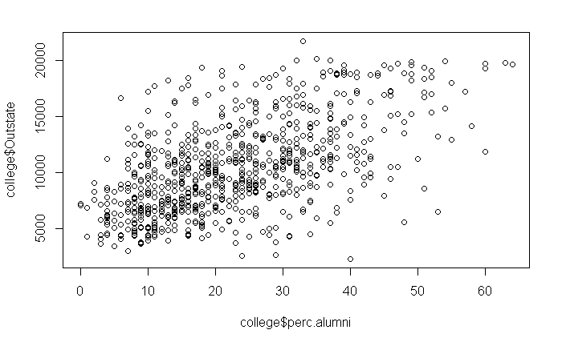

```r
## This plot shows that schools with higher out of state tuition tend to have higher graduation rates

plot(college$perc.alumni, college$Outstate)
```

## Exercise 9

1. Quantitative Predictors: mpg, cylinders, displacement, horsepower, weight, acceleration, year

Qualitative Predictors: origin, name

```r
range(Auto$mpg)
```

```
[1]  9.0 46.6
```

```r
range(Auto$cylinders)
```

```
[1] 3 8
```

```r
range(Auto$displacement)
```

```
[1]  68 455
```

```r
range(Auto$horsepower)
```

```
[1]  46 230
```

```r
range(Auto$weight)
```

```
[1] 1613 5140
```

```r
range(Auto$acceleration)
```

```
[1]  8.0 24.8
```

```r
range(Auto$year)
```

```
[1] 70 82
```

```r
sapply(Auto[,1:7], mean)
```

```
         mpg    cylinders displacement   horsepower       weight acceleration         year
   23.445918     5.471939   194.411990   104.469388  2977.584184    15.541327    75.979592
```

```r
sapply(Auto[,1:7], sd)
```

```
         mpg    cylinders displacement   horsepower       weight acceleration         year
    7.805007     1.705783   104.644004    38.491160   849.402560     2.758864     3.683737
```

```r
temp = Auto[-(10:85),]
sapply(temp[,1:7], range)
```

```
      mpg cylinders displacement horsepower weight acceleration year
[1,] 11.0         3           68         46   1649          8.5   70
[2,] 46.6         8          455        230   4997         24.8   82
```

```r
sapply(temp[,1:7], mean)
```

```
         mpg    cylinders displacement   horsepower       weight acceleration         year
   24.404430     5.373418   187.240506   100.721519  2935.971519    15.726899    77.145570
```

```r
sapply(temp[,1:7], sd)
```

```
         mpg    cylinders displacement   horsepower       weight acceleration         year
    7.867283     1.654179    99.678367    35.708853   811.300208     2.693721     3.106217
```

[output not shown]

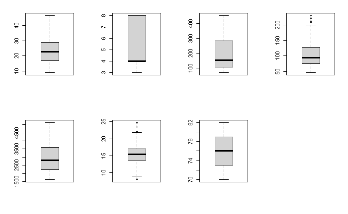

```r
par(mfrow=c(2,4))
sapply(Auto[,1:7], boxplot)
```

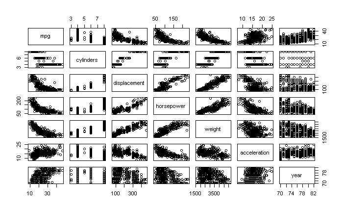

```r
pairs(Auto[,1:7])
```

5. The plots suggest that the year, weight, horsepower, and displacement all could be used to predict the mpg of a car. All these variables have a pretty strong correlation with mpg as shown in the scatter plots above. Since displacement, horsepower, and weight correlate with each other, these variables should be selected carefully to avoid confounding variables.

## Exercise 10

1. This dataset has 506 rows and 14 columns. The rows and columns represent data on housing values in Boston

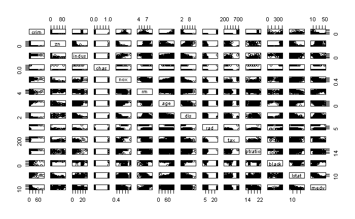

```r
pairs(Boston)
```

Some of the relationships are nitrogen oxides concentraion and distance to employment centres, age and lower status of the population, and rooms and lower status of the population. The predictors that are most correlated with price are number of rooms and lower status of the population.

3. There aren’t any strong linear correlations with the crime rate. However, the crime rate is only high when some predictors are equal to a certain value. For example, crime rate is only high in areas with no lots over 25,000 sq ft, accessibility to radial highways is high, higher property tax, and higher pupil teacher ratio. This likely due to the fact that crime is high in a certain area of Boston that has similar values for all of these predictors.

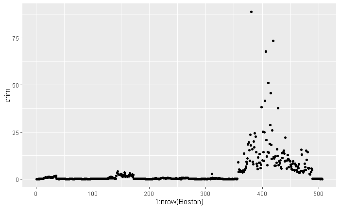

```r
g <- ggplot(Boston, aes(x=1:nrow(Boston), y=crim))
g + geom_point()
```

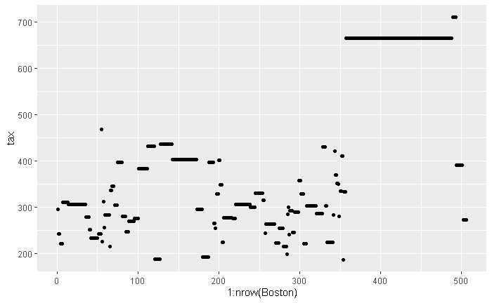

```r
g <- ggplot(Boston, aes(x=1:nrow(Boston), y=tax))
g + geom_point()
```

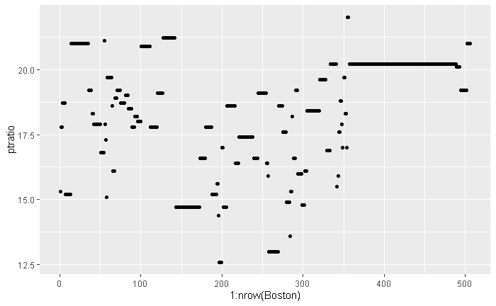

```r
g <- ggplot(Boston, aes(x=1:nrow(Boston), y=ptratio))
g + geom_point()
```

Crim and tax both have very large ranges due to some high outliers. Ptratio doesn’t appear to have any clear outliers. The outliers for tax and crime rates appear to be the same suburbs so these are likely correlated.

```r
table(Boston$chas)
```

```
  0   1
471  35
```

There are 35 towns that bound the Charles river.

```r
median(Boston$ptratio)
```

```
[1] 19.05
```

19.05 is the median pupil teacher ratio

```r
(towns = Boston[Boston$medv == min(Boston$medv),])
```

|  | crim | zn | indus | chas | nox | rm | age | dis | rad | tax | ptratio | black | lstat | medv |
| --- | --- | --- | --- | --- | --- | --- | --- | --- | --- | --- | --- | --- | --- | --- |
| 399 | 38.3518 | 0 | 18.1 | 0 | 0.693 | 5.453 | 100 | 1.4896 | 24 | 666 | 20.2 | 396.90 | 30.59 | 5 |
| 406 | 67.9208 | 0 | 18.1 | 0 | 0.693 | 5.683 | 100 | 1.4254 | 24 | 666 | 20.2 | 384.97 | 22.98 | 5 |

```r
sapply(Boston, quantile)
```

```
          crim    zn indus chas   nox     rm     age       dis rad tax ptratio    black  lstat   medv
0%    0.006320   0.0  0.46    0 0.385 3.5610   2.900  1.129600   1 187   12.60   0.3200  1.730  5.000
25%   0.082045   0.0  5.19    0 0.449 5.8855  45.025  2.100175   4 279   17.40 375.3775  6.950 17.025
50%   0.256510   0.0  9.69    0 0.538 6.2085  77.500  3.207450   5 330   19.05 391.4400 11.360 21.200
75%   3.677083  12.5 18.10    0 0.624 6.6235  94.075  5.188425  24 666   20.20 396.2250 16.955 25.000
100% 88.976200 100.0 27.74    1 0.871 8.7800 100.000 12.126500  24 711   22.00 396.9000 37.970 50.000
```

There are 2 suburbs with the lowest median house value. The areas have above average crime rate, proportion of non-retatil businesses, nitrogen oxide levels, house ages, pupil-teacher ratio, accessibility to radial highways, property tax, and lower status of the population. They also are close to employment centres.

```r
nrow(Boston[Boston$rm > 7,])
```

```
[1] 64
```

```r
nrow(Boston[Boston$rm > 8,])
```

```
[1] 13
```

```r
rbind(sapply(Boston[Boston$rm > 8,], mean), sapply(Boston, median))
```

```
          crim       zn    indus      chas       nox       rm      age      dis      rad      tax  ptratio
[1,] 0.7187954 13.61538 7.078462 0.1538462 0.5392385 8.348538 71.53846 3.430192 7.461538 325.0769 16.36154
[2,] 0.2565100  0.00000 9.690000 0.0000000 0.5380000 6.208500 77.50000 3.207450 5.000000 330.0000 19.05000
        black lstat medv
[1,] 385.2108  4.31 44.2
[2,] 391.4400 11.36 21.2
```

There are 64 suburbs that average more than 7 rooms and 13 suburbs that average more than 8 rooms per house. These suburbs have higher crime rates, lower pupil teacher ratios, and a lower lstat. These suburbs also have more expensive median home prices.